# **Capítulo 3: Integrais**

## **Uma Breve Abordagem Histórica**

Podemos remontar a história do Cálculo desde antes da Era Comum. Alguns dos primeiros registros advém do período de Sesóstris II, quarto faraó da décima segunda dinastia egípcia, um manuscrito que elaborava métodos para o cálculo de áreas de uma pirâmide. Há registros, também, de que astrônomos babilônicos utilizavam técnicas semelhantes para calcular a órbita de planeas. Já durante a Antiguidade, matemáticos gregos como Demócrito de Abdera, Zenão de Eleia e Arquimedes de Siracusa desenvolveram técnicas para resolução de problemas geométricos cujas raízes estão intimamente conectadas aos fundamentos do Cálculo. Foi Arquimedes, inclusive, quem propôs o **método da exaustão**, que futuramente seria descoberto cerca de seis séculos mais tarde por um matemático chinês chamado Liu Hui.

#### **Figura 1.** Esquematização do método da exaustão

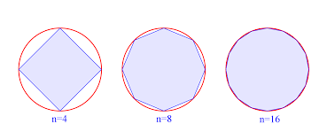

Ao longo séculos, matemáticos de diferentes locais do globo buscavam soluções para problemas envolvendo, especialmente, o estudo dos astros e da geometria. Foi o caso do matemático e físico persa Abu Ali al-Hasan Ibn Al-Haitham, que foi capaz de calcular o volume de sólidos utilizando conceitos primitivos de **integrais** ainda no século X.  
Assim, podemos dizer que o estudo das integrais existe há milênios, ainda que não fosse chamado dessa forma. Você mesmo, leitor, já deve ter resolvido uma integral sem perceber. Primeiramente, prestemos atenção à figura 1. Nela, um círculo é progressivamente aproximado por polígonos com maior número de faces. Esse método, já mencionado anteriormente, é chamado de método da exaustão, e consiste em aproximar aproximar a área de um círculo pela área de um polígono cuja área seja conhecida, de forma que, para um número de lados suficientemente elevado, as **diferenças** entre as áreas do polígono e do círculo sejam suficientemente pequenas. Perceba que, quanto maior o número de lados do polígono, mais próxima sua área é da área do círculo, bem como menores são o comprimento de cada lado.

Pense então, por um momento, qual seria a melhor forma de se obter a área real de um círculo. Se utilizamos o que foi aprendido no capítulo 2, podemos extrapolar o método da exaustão e dizer que, para um polígono com um número de lados infinitamente elevado, com comprimento de cada lado infinitamente pequeno, a área do polígono é exatamente igual à área do círculo. Uma vez que um polígono de *n*-lados pode ser representado por um número *n* de triângulos retângulos, a área desse polígono será exatamente igual à soma das áreas dos *n* triângulos retângulos. Assim, se o número de lados desse polígono tender ao infinito, e uma vez que nesse caso a sua área será exatamente igual à área de um círculo, então a área do círculo será exatamente igual à soma das áreas dos *n* triângulos retângulos que o compõe. A esse processo, damos o nome de **integração**. Perceba, portanto, a semelhança entre desse raciocínio com aquele utilizado para definir derivadas. Em ambas as situações, seja para derivar, seja para integrar, estamos utilizando o conceito de **limites** para tornar um elemento em um **elemento infinitesimal** para, em seguida, aplicar conceitos que já conhecemos. Neste caso, como ilustra a figura 2, estamos tornando o cateto indicado por *a* em um cateto infinitamente pequeno, tendo seu valor tendendo a zero, sendo este, portanto, um elemento infinitesimal.

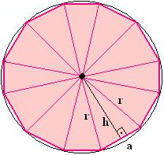

Agora que entendemos o conceito, vamos buscar compreender como aplicá-lo. Considere um retângulo com altura igual a 4 e largura igual a 5, e que este retângulo está apresentado num plano cartesiano como mostrado abaixo.

```python
import numpy as np
import matplotlib.pyplot as plt
import matplotlib.patches as patches
```

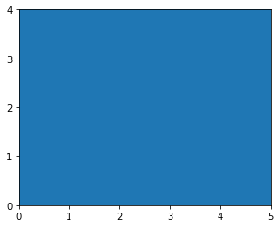

```python
xy = (0, 0)

largura = 5
altura = 4

x = [0, 1, 2, 3, 4, 5]
y = [0, 1, 2, 3, 4]

fig, ax = plt.subplots(figsize = (largura, altura))

retangulo = patches.Rectangle(xy, largura, altura)

ax.add_patch(retangulo)

plt.xticks(np.arange(min(x), max(x)+1, 1))
plt.yticks(np.arange(min(y), max(y)+1, 1))

plt.show(retangulo)
```

Vamos, agora, dividir esse retângulo em um conjunto de retângulos menores, com altura idêntica à do retângulo original, mas com comprimentos $\Delta$x = 0,1.

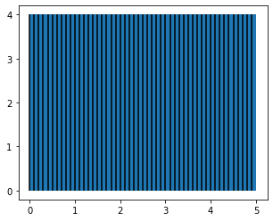

```python
def retangulo_segmentado(delta_x):

    fig, ax = plt.subplots(figsize = (largura, altura))

    retangulo = patches.Rectangle(xy, largura, altura)

    ax.add_patch(retangulo)

    plt.xticks(np.arange(min(x), max(x)+1, 1))
    plt.yticks(np.arange(min(y), max(y)+1, 1))
    plt.vlines(np.arange(min(x), max(x), delta_x), min(y), max(y))

    plt.show(retangulo)

delta_x = 0.1

retangulo_segmentado(delta_x)
```

Vamos realizar o mesmo procedimento novamente, mas agora modificando $\Delta$x para apresentar valores cada vez menores e verificar o que ocorre com o retângulo em azul.

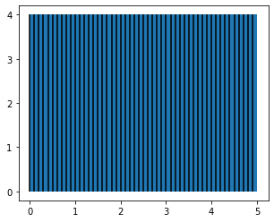

```
Δx =  0.1
```

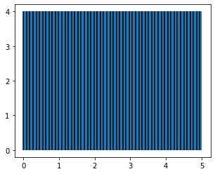

```
Δx =  0.09
```

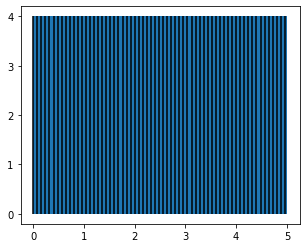

```
Δx =  0.08
```

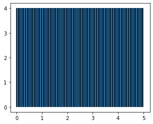

```
Δx =  0.07
```

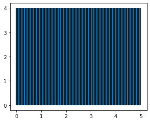

```
Δx =  0.06
```

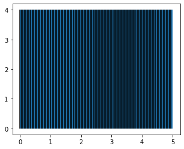

```
Δx =  0.05
```

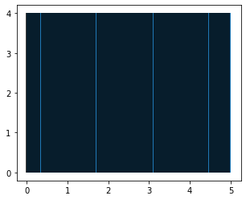

```
Δx =  0.04
```

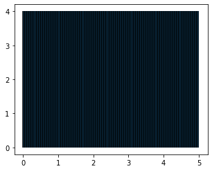

```
Δx =  0.03
```

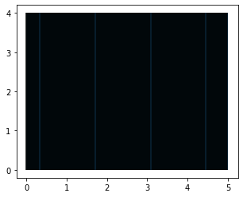

```
Δx =  0.02
```

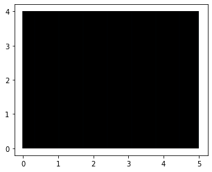

```
Δx =  0.01
```

```python
vetor_delta_x = np.arange(0.1, 0.005, -0.01)

for delta_x in vetor_delta_x:

    retangulo_segmentado(delta_x)
    print('\u0394x = ', round(delta_x, 2))
    print(' ')
```

De forma matemática, podemos descrever esse procedimento como:

\begin{equation*} A_{retangulo} = \sum\limits_{n=0}^{N} y \cdot \Delta x_{n} \; \; \; \; \; \; (1) \end{equation*}

Sendo:

- N o número de retângulos
- $\Delta x$ o comprimento de cada um desses retângulos

Se, no entanto, fizermos com que o número de retângulos tenda ao infinito, ao passo que o comprimento de cada um desses retângulos tenda a zero, teremos que: \begin{equation*} A_{retangulo} = \lim_{N\rightarrow \infty} \sum\limits_{n=0}^{N} y \cdot \lim_{\Delta \rightarrow 0} \Delta x_{n} \; \; \; \; \; \; (2) \end{equation*} Para melhor visualizar o significado da equação (2), iremos recorrer à figura 3. Nela, a área de uma curva qualquer, f(x), é aproximada por uma soma de retângulos, de forma que, quando $\Delta$x tenda a zero, conforme explicado acima.

#### **Figura 3.** Visualização da aproximação da área sob uma curva pela soma da área de retângulos.

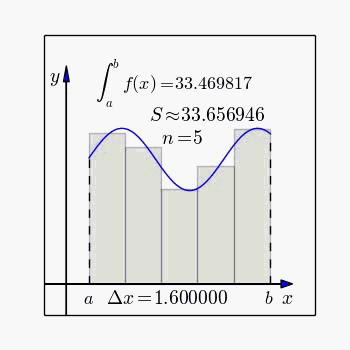

Essa forma de escrever integrais, no entanto, é pouco conveniente. Podemos, ao invés disso, chamar dizer que: \begin{equation*} dx = \lim_{\Delta \rightarrow 0} \Delta x \; \; \; \; \; \; (3) \end{equation*} Para tornar ainda mais simples, podemos usar uma nova nomenclatura para o símbolo de somatório, e que é a forma mais comum de representarmos uma integral: \begin{equation*} A_{retangulo} = \int y \cdot dx \; \; \; \; \; \; (4) \end{equation*} Agora, note: quando falávamos em derivadas, estávamos nos referindo à inclinação da reta tangente para um ou mais pontos de uma determinada curva. Aqui, estamos interessados em descobrir a **área sob a curva** de uma função para um ou mais pontos. Assim, se chamarmos esta curva de f(x), a sua integral será a área abaixo dessa curva. Ou seja: \begin{equation*} A_{f(x)} = \int f(x) \cdot dx \; \; \; \; \; \; (5) \end{equation*} A área de f(x), $A_{f(x)}$ é também uma função. Vamos chamar ela, portanto, de *g(x)*. Podemos reescrever a equação (5) como: \begin{equation*} g(x) = \int f(x) \cdot dx \; \; \; \; \; \; (5) \end{equation*} Mas e se, ao invés de conhecermos *f(x)*, conhecermos apenas a sua integral, *g(x)*? Pense um pouco sobre isso por um momento. Primeiro, consideremos o gráfico de f(x) e área sob ela.

#### **Figura 4.** Curva de uma função genérica f(x) e área sob ela.

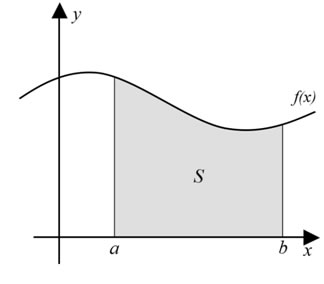

Se desejarmos conhecer a curva f(x), podemos simplesmente fazer o caminho contrário: se conhecemos a área sob a curva f(x), sabemos a área de cada retângulo infinitesimal que a compõe. Sabemos, também, a altura de cada retângulo, nesse caso, um valor genérico chamado *y*. Assim, para saber o valor da função f(x) em um determinado ponto, basta sabermos o valor da base desse retângulo, no caso, $\Delta x$. A figura 5 ilustra de forma mais clara esse procedimento.

#### **Figura 5.** Área sob a curva f(x) aproximada pela soma de retângulos. Cada retângulo possui uma altura y e uma base dada por $\Delta x$.

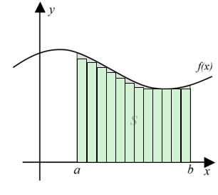

Se, no entanto, $\Delta x$ tender à zero, de forma que $\Delta x$ = *dx*, a aresta *dx* do retângulo infinitesimal será **igual** à **inclinação da reta tangente** para um determinado ponto. Em outras palavras, significa que para descobrirmos o valor de f(x), devemos **derivar** g(x). Da mesma forma, se desejarmos descobrir g(x), devemos **integrar** f(x). Isso significa, portanto que: \begin{equation*} g'(x) = f(x) \; \; \; \; \; \; (6) \end{equation*} Assim, a integral é a função inversa da derivada, razão pela qual integrais também são conhecidas como **antiderivadas**. Ou seja, se derivarmos uma função e em seguida a integrarmos, o resultado será a própria função. Matematicamente falando, isso significa que: \begin{equation*} f(x) = \int g'(x) \cdot dx \; \; \; \; \; \; (7) \end{equation*} $$ \\ $$

### **Exemplo 1**

$$ \\ $$ Considerando, novamente, o problema populacional apresentado no capítulo anterior, mas agora ao invés de dispormos da equação referente à população, dispomos ao invés disso da taxa de crescimento populacional. Isso significa que sabemos a seguinte equação: $$ \\ $$ \begin{equation*} \frac{dN}{dt} = 2 \cdot N_{0} \cdot exp(r \cdot t) + C\; \; \; \; \; \; (8) \end{equation*} Onde *C* é uma **constante de integração**, que nada mais é do que um valor desconhecido que aparece quando integramos uma equação e não determinamos o **intervalo de integração**, apresentado nas figuras 3, 4 e 5 por *a* e *b*. $$ \\ $$ Para obter a equação populacional, podemos então realizar a integração da equação (8) de forma que: $$ \\ $$ \begin{equation*} \int dN = \int 2 \cdot N_{0} \cdot exp(r \cdot t) dt \; \; \; \; \; \; (9) \end{equation*} $$ \\ $$ Utilizando algumas das propriedades de integração, chegamos à equação (13) do capítulo 2. Assim: $$ \\ $$ \begin{equation*} \int dN = N(t) = N_{0} \cdot exp(r \cdot t) \; \; \; \; \; \; (10) \end{equation*} $$ \\ $$

### **Exemplo 2**

Utilizando-nos das integrais, podemos, inclusive, resolver **equações diferenciais**, como a apresentada abaixo. Nela, é apresentado o crescimento populacional do protosoário *Paramecium bursaria*, que habita águas salgadas. O seu crescimento pode ser descrito como: \begin{equation*} \frac{dN}{dt} = b \cdot F \cdot N \; \; \; \; \; \; (11) \end{equation*} Onde: * $\frac{dN}{dt}$ é a taxa de crescimento populacional da *Paramecium bursaria* * N é a população do protosoário em um determinado instante * b é um coeficiente de proporcionalidade * F é a disponibilidade de alimento Perceba que, neste caso, a única equação conhecida é a equação (11), e desconhecemos a equação que governa o número de indivíduos da população, *N(t)*. Nosso trabalho, agora, é justamente encontrar esta equação a partir da equação (11). Assim, manipulando a equação, teremos que: $$ \\ $$ \begin{equation*} \frac{dN}{N} = b \cdot F \cdot dt \; \; \; \; \; \; (12) \end{equation*} $$ \\ $$ Aplicando integrais em ambos os lados da equação (12), obteremos: $$ \\ $$ \begin{equation*} \ int \frac{dN}{N} = \int b \cdot F \cdot dt \; \; \; \; \; \; (13) \end{equation*} $$ \\ $$ Resolvendo a equação (13) utilizando algumas técnicas de integração, tem-se, então, que: $$ \\ $$ \begin{equation*} ln(N) = b \cdot F \cdot t + C \; \; \; \; \; \; (14) \end{equation*} $$ \\ $$ E, para tornar a equação (14) mais amigável e aplicável, podemos reescrevê-la como: $$ \\ $$ \begin{equation*} N(t) = C \cdot e^{b \cdot F \cdot t} \; \; \; \; \; \; (15) \end{equation*} $$ \\ $$ Agora, se definirmos que no instante inicial, para *t = 0*, a população inicial é igual a 5 indivíduos, e aplicando iso na equação (15): $$ \\ $$ \begin{equation*} N(0) = N_{0} = 5 = C \cdot e^{b \cdot F \cdot 0} \; \; \; \; \; \; (16) \end{equation*} $$ \\ $$ Uma vez que qualquer número elevado à 0 é igual a 1, então a equação (16) torna-se: $$ \\ $$ \begin{equation*} N(0) = N_{0} = 5 = C \cdot 1 \; \; \; \; \; \; (17) \end{equation*} $$ \\ $$ O que nos leva à conclusão de que o valor de C, para esse caso, é igual ao valor do número de indivíduos da população inicial, $N_{0}$, que é de 5 indivíduos. E, portanto, aplicando o resultado da equação (17) em (15), temos que: $$ \\ $$ \begin{equation*} N(t) = N_{0} \cdot e^{b \cdot F \cdot t} \; \; \; \; \; \; (15) \end{equation*} $$ \\ $$ Podemos, agora, graficar esse resultado, se assim desejarmos. Considerando que *F* = 2 e *b* = 0,2, teremos que: $$ \\ $$

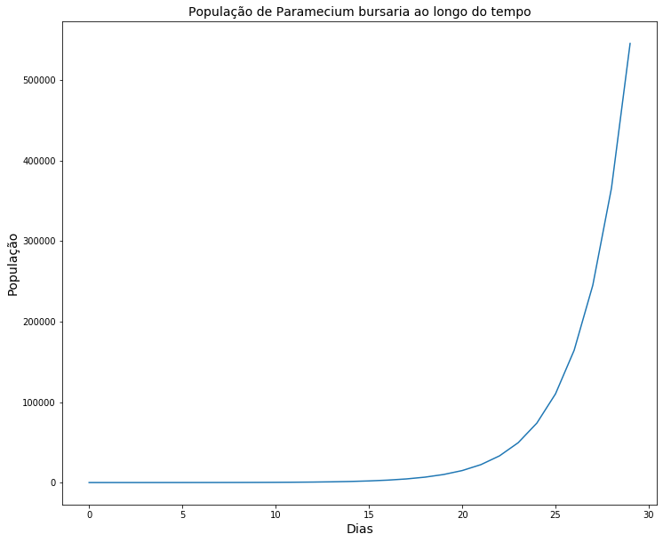

```python
b = 0.2
F = 2
N0 = 5

t = np.arange(0, 30, 1)

N = N0*np.exp(b*F*t, dtype=np.float64)

plt.figure(figsize=(12, 10))
plt.plot(t, N)
plt.title('População de Paramecium bursaria ao longo do tempo', fontsize=14)
plt.xlabel('Dias', fontsize=14)
plt.ylabel('População', fontsize=14)
```